# Correlation between Health diet and COVID-19

Written by SEOYEONKIM

2020 6 8

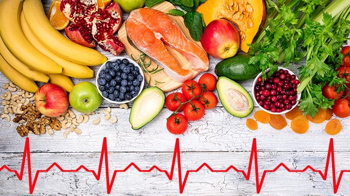

## (1) LINEAR REGRESSION

### 1단계: 데이터 수집

요즘 전세계는 코로나19로 떠들썩하다. 코로나에 대응하기 위해서 사람들이 어떤 노력을 할 수 있을지에 대해 생각을 해보다가, 식습관이 코로나 발병률에 영향을 주는지가 궁금해졌다. 이 분석은 Kaggle.com에서 제공하는 나라별 각 식품 군에서 섭취한 지방량, 비만률, 코로나 발병률 등이 담긴 데이터셋을 사용한다. 나라이름은 각각의 행이름에 불과하기 때문에 사용하지 않고, 몇가지 음식 지방량과 비만률이 코로나 발병률과 어떠한 상관관계가 있는지 알아보고자 한다.

*다음은 사용하고자 하는 변수들의 설명이다.*

1. **Animal fats**
- Butter, Ghee, Cream, Fats, Animals, Raw Fish, Body Oil, Fish, Liver Oil
2. **Animal Products**
- Aquatic Animals, Others; Aquatic Plants; Bovine Meat; Butter, Ghee; Cephalopods; Cream; Crustaceans; Demersal Fish; Eggs; Fats, Animals, Raw; Fish, Body Oil; Fish, Liver Oil; Freshwater Fish; Marine Fish, Other; Meat, Aquatic Mammals; Meat, Other; Milk - Excluding Butter; Molluscs, Other; Mutton & Goat Meat; Offals, Edible; Pelagic Fish; Pigmeat; Poultry Meat
3. **Vegetal Products**
- Alcohol, Non-Food; Apples and products; Bananas; Barley and products; Beans; Beer; Beverages, Alcoholic; Beverages, Fermented; Cassava and products; Cereals, Other; Citrus, Other; Cloves; Cocoa Beans and products; Coconut Oil; Coconuts - Incl Copra; Coffee and products; Cottonseed; Cottonseed Oil; Dates; Fruits, Other; Grapefruit and products; Grapes and products (excl wine); Groundnut Oil; Groundnuts (Shelled Eq); Honey; Infant food; Lemons, Limes and products; Maize and products; Maize Germ Oil; Millet and products; Miscellaneous; Nuts and products; Oats; Oilcrops Oil, Other; Oilcrops, Other; Olive Oil; Olives (including preserved); Onions; Oranges, Mandarines; Palm kernels; Palm Oil; Palmkernel Oil; Peas; Pepper; Pimento; Pineapples and products; Plantains; Potatoes and products; Pulses, Other and products; Rape and Mustard Oil; Rape and Mustardseed; Rice (Milled Equivalent); Ricebran Oil; Roots, Other; Rye and products; Sesame seed; Sesameseed Oil; Sorghum and products; Soyabean Oil; Soyabeans; Spices, Other; Sugar (Raw Equivalent); Sugar beet; Sugar cane; Sugar non-centrifugal; Sunflower seed; Sunflowerseed Oil; Sweet potatoes; Sweeteners, Other; Tea (including mate); Tomatoes and products; Vegetables, Other; Wheat and products; Wine; Yams
4. **Seafood**
- Cephalopods; Crustaceans; Demersal Fish; Freshwater Fish; Marine Fish, Other; Molluscs, Other; Pelagic Fish
5. **Spices**
- Cloves; Pepper; Pimento; Spices, Other
6. **Obesity**
- the percentage of obesity rate
7. **Confirmed**
- the percentage of COVID-19 Confirmed rate

1~5번 변수들은 각각 아래에 정렬되어 있는 음식들에 들어있는 **지방 섭취량(fat supply)**을 의미한다.모든 변수의 값은 전체 인구 대비 %값이다. 따라서, 나라와 인구는 생각하지 않고, 위에 있는 변수들 간의 관계만을 생각한다. 1~6의 독립변수들이 코로나 발병률과 어떻게 관련되어 있는지 생각해보는 것이 중요하다.

### 2단계: 데이터 탐색과 준비

위의 변수 이름들중 몇개는 띄어쓰기가 되어있어 R에서 이름인식이 잘 되지않을 것이다. 그래서, 띄어쓰기 대신 _만 붙여 준 후 R에 로드한다. **read.csv()** 함수를 사용해 분석할 데이터를 로드한다. 데이터의 열 이름을 그대로 사용하기 위해, **header=TRUE**를 사용한다.  
그 후, 데이터가 잘 구성되었는지 **str()**함수로 확인한다.

```r
corona <- read.csv("C:/Users/KSY/Desktop/health diet &corona/Fat_Supply_Quantity_Data.csv", header=TRUE)
str(corona)
```

```
## 'data.frame':    170 obs. of  32 variables:
##  $ Country                     : Factor w/ 170 levels "Afghanistan",..: 1 2 3 4 5 6 7 8 9 10 ...
##  $ Alcoholic.Beverages         : num  0 0 0 0 0 0 0 0 0 0 ...
##  $ Animal_Products             : num  21.6 32 14.4 15.3 27.7 ...
##  $ Animal_fats                 : num  6.222 3.417 0.897 1.313 4.669 ...
##  $ Aquatic.Products..Other     : num  0 0 0 0 0 0 0 0 0 0 ...
##  $ Cereals...Excluding.Beer    : num  8.04 2.67 4.2 6.55 3.22 ...
##  $ Eggs                        : num  0.686 1.645 1.217 0.154 0.387 ...
##  $ Seafood                     : num  0.0327 0.1445 0.2008 1.4155 1.5263 ...
##  $ Fruits                      : num  0.425 0.642 0.577 0.349 1.218 ...
##  $ Meat                        : num  6.12 8.74 3.9 11.03 14.32 ...
##  $ Miscellaneous               : num  0.0163 0.017 0.0439 0.0308 0.0898 0 0.0361 0.052 0 0.017 ...
##  $ Milk...Excluding.Butter     : num  8.28 17.76 8.09 1.23 6.66 ...
##  $ Offals                      : num  0.31 0.293 0.107 0.154 0.135 ...
##  $ Oilcrops                    : num  1.05 3.16 1.2 3.99 1.36 ...
```

[output cut: 18 more lines]

#### 데이터 전처리

분석에 적합하게 데이터를 가공하는 작업을 데이터 전처리라고 한다. 데이터 전처리 작업에 사용되는 **dplyr**패키지를 로드한다. **dplyr**패키지의 **select()**함수를 이용해 필요한 변수만 추출한다.  
**str()**을 통해 총 7개의 **numeric**변수가 잘 로드 된것을 볼 수 있다.  
모델의 종속 변수는 **Confirmed**로 각 행에 있는 음식지방 섭취량과 비만율을 가진 사람들의 코로나 확진 비율을 나타낸 값이다.

```r
library(dplyr)
corona <- corona %>% select(Animal_Products, Animal_fats, Vegetal_Products,Seafood, Spices,Obesity,Confirmed)
str(corona)
```

```
## 'data.frame':    170 obs. of  7 variables:
##  $ Animal_Products : num  21.6 32 14.4 15.3 27.7 ...
##  $ Animal_fats     : num  6.222 3.417 0.897 1.313 4.669 ...
##  $ Vegetal_Products: num  28.4 18 35.6 34.7 22.3 ...
##  $ Seafood         : num  0.0327 0.1445 0.2008 1.4155 1.5263 ...
##  $ Spices          : num  0.2776 0 0.1568 0.0103 0.3591 ...
##  $ Obesity         : num  4.5 22.3 26.6 6.8 19.1 28.5 20.9 30.4 21.9 19.9 ...
##  $ Confirmed       : num  0.039969 0.039783 0.021642 0.000274 0.026804 ...
```

**is.na()**을 사용하면 데이터에 결측치가 들어있는지 알 수 있다. **table(is.na())**을 적용하여 데이터에 결측치가 총 몇 개 있는지 출력한다. TRUE의 빈도를 보면 결측치가 12개 있다는 것을 알 수 있다.

```r
table(is.na(corona))
```

```
##
## FALSE  TRUE
##  1178    12
```

구체적으로 어떤 변수에 결측치가 있는지 보기위해 **table(is.na())**에 변수명을 지정하였다.  
아래 코드를 보면 **Obesity**와 **Confirmed**에 각각 3개, 9개가 있다는 것을 알 수 있다.

```r
table(is.na(corona$Obesity))
```

```
##
## FALSE  TRUE
##   167     3
```

```r
table(is.na(corona$Confirmed))
```

```
##
## FALSE  TRUE
##   161     9
```

따라서, **filter()**의 **&**기호를 이용해 조건을 나열하면, 이 두 변수에 모두 결측치가 없는 행을 새로운 **corona_new**변수에 추출할 수 있다.  
**str()**을 통해 170개 였던 데이터가 전처리 후 160개로 바뀐 것을 확인 할수있다.

```r
corona_new <- corona %>% filter(!is.na(Obesity)  & !is.na(Confirmed))
table(is.na(corona_new))
```

```
##
## FALSE
##  1120
```

```r
str(corona_new)
```

```
## 'data.frame':    160 obs. of  7 variables:
##  $ Animal_Products : num  21.6 32 14.4 15.3 27.7 ...
##  $ Animal_fats     : num  6.222 3.417 0.897 1.313 4.669 ...
##  $ Vegetal_Products: num  28.4 18 35.6 34.7 22.3 ...
##  $ Seafood         : num  0.0327 0.1445 0.2008 1.4155 1.5263 ...
##  $ Spices          : num  0.2776 0 0.1568 0.0103 0.3591 ...
##  $ Obesity         : num  4.5 22.3 26.6 6.8 19.1 28.5 20.9 30.4 21.9 19.9 ...
##  $ Confirmed       : num  0.039969 0.039783 0.021642 0.000274 0.026804 ...
```

다음은 데이터의 요약 통계를 보여준다. 평균값이 중앙값보다 크기 때문에, 코로나 확진률 분포는 오른쪽으로 꼬리가 긴 분포다. **hist()**을 통해 분포를 시각적으로 확인할 수 있다.  
확률 분포를 보면 대부분이 0에서 0.1사이에 있고 오른쪽으로 꼬리가 긴 분포임을 알 수 있다.

```r
summary(corona_new$Confirmed)
```

```
##      Min.   1st Qu.    Median      Mean   3rd Qu.      Max.
## 0.0000941 0.0097051 0.0280948 0.1031408 0.1283605 0.6480645
```

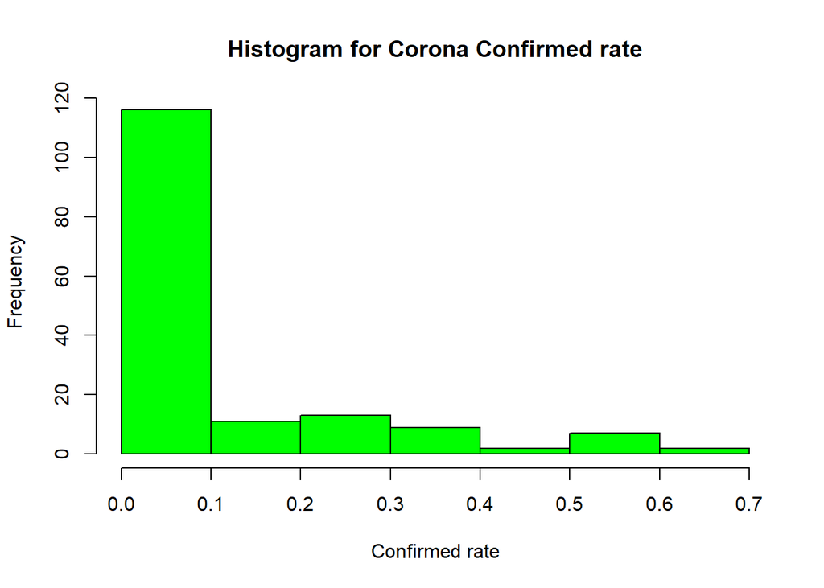

```r
hist(corona_new$Confirmed, main="Histogram for Corona Confirmed rate",xlab="Confirmed rate",border="black"
     ,col="green")
```

#### 특징 간 관계 탐색: 상관행렬

회귀모델을 데이터에 적합시키기 전에 독립 변수가 종속 변수와 어떤 관계를 가지는지 알아보는 것이 중요하다. **상관 행렬**은 이러한 관계에 대한 요약을 제공한다. **cor()** 명령을 이용하여 **corona_new** 데이터 프레임에 있는 6개의 수치 변수에 관한 상관행렬을 생성한다.

```r
cor(corona_new[c("Animal_Products","Animal_fats","Vegetal_Products","Seafood","Spices","Obesity","Confirmed")])
```

```
##                  Animal_Products Animal_fats Vegetal_Products      Seafood
## Animal_Products      1.000000000   0.6837163     -0.999999855  0.004194152
## Animal_fats          0.683716299   1.0000000     -0.683703920 -0.102092750
## Vegetal_Products    -0.999999855  -0.6837039      1.000000000 -0.004245142
## Seafood              0.004194152  -0.1020928     -0.004245142  1.000000000
## Spices              -0.187724220  -0.2069006      0.187638449  0.238484775
## Obesity              0.475672511   0.4307724     -0.475660492 -0.240079954
## Confirmed            0.316090708   0.2970380     -0.316124801  0.056206350
##                      Spices    Obesity   Confirmed
## Animal_Products  -0.1877242  0.4756725  0.31609071
## Animal_fats      -0.2069006  0.4307724  0.29703798
## Vegetal_Products  0.1876384 -0.4756605 -0.31612480
## Seafood           0.2384848 -0.2400800  0.05620635
## Spices            1.0000000 -0.2312019 -0.13708207
## Obesity          -0.2312019  1.0000000  0.41250423
## Confirmed        -0.1370821  0.4125042  1.00000000
```

각 행과 열이 만나는 지점에서 해당 행과 열이 가리키는 변수의 상관관계가 나열된다. 따라서, 대각선은 자신의 변수끼리의 상관관계를 나타내는 것이므로 항상 1을 나타내고, 대각선을 기준으로 대칭이기 때문에 위 아래 값은 동일하다. **cor()**값은 -1부터 1까지이며, 그것의 절댓값이 0.5가 넘어가면 강한 상관관계를 나타낸다.  
결과를 보면, 어떠한 독립변수들도 종속변수와의 상관계수가 0.5을 넘지 않는다. 그래도, 눈에 띄는 것은 **Animal_Products**와 **Obesity**는 **Confirmed**와 **약한 양의 상관관계**를 가지고, **Vegetal_Products** 은 **Confirmed**와 **약한 음의 상관관계**를 가지는 것이다. 이러한 연관성은, **Animal Porducts**와 **Obesity**가 높을수록 코로나 발병률이 높아진다는 것, 그리고 **Vegetal Products**가 높을수록 코로나 발병률이 낮아진다는 것을 의미한다.  
최종 회귀 모델 구축을 통해, 이러한 관계를 좀 더 정확하게 알아볼 것이다.

#### 특징 간 관계 시각화: 산포도 행렬

**산포도 행렬**을 통해 수치 특징 간의 관계를 시각화 할 수 있다. 한번에 두개의 특징만을 관찰하기 때문에, 데이터가 어떻게 상호 연관되어 있는지 일반적인 이해를 제공한다. 6개의 독립변수가 있기 때문에, 효과적인 시각화를 위해 3개씩 두번에 나누어서 산포도를 생성 할 것이다.

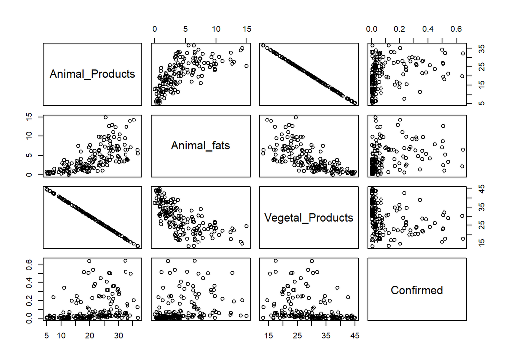

```r
pairs(corona_new[c("Animal_Products","Animal_fats","Vegetal_Products","Confirmed")])
```

산포도 행렬에서 각 행과 열의 교차점에는 행, 열 쌍이 가리키는 변수의 산포도가 있다. 다이어그램은 x축과 y축을 바꾼 것이기 때문에 전치다. 무작위 구름처럼 보이는 것도 있지만, **Animal_Products**와 **Vegetal_Products**는 상대적으로 직선으로 어떤 추세를 미세하게나마 어떤 추세를 나타내는 듯 하다.

**psych**패키지의 **pairs.panels()**함수를 사용하면, **Correlation**과 **Scattered plot**을 동시에 보여주는 좀 더 유익한 산포도 행렬을 생성할 수 있다.

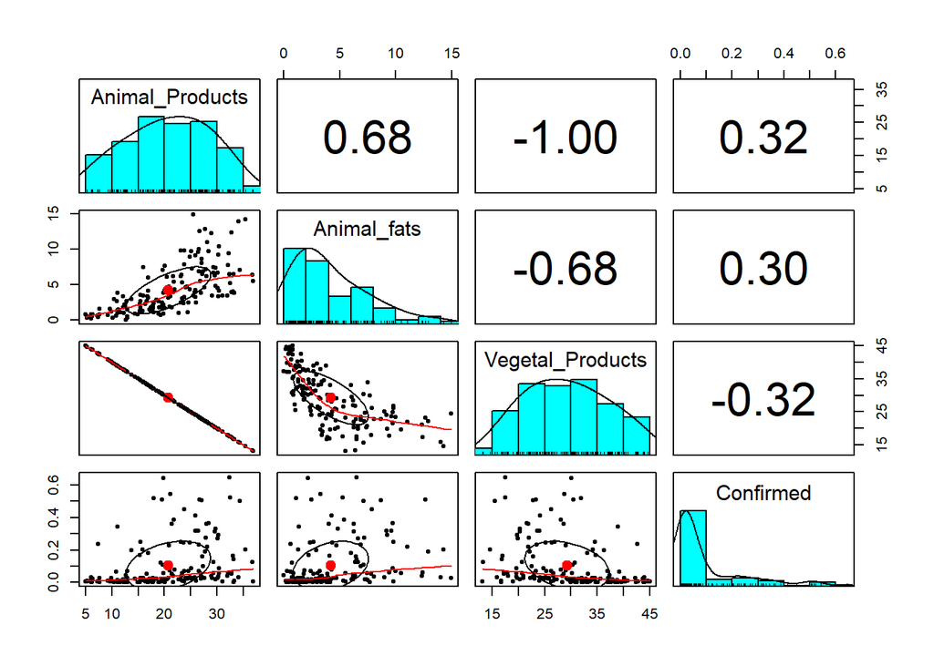

```r
library(psych)
pairs.panels(corona_new[c("Animal_Products","Animal_fats","Vegetal_Products","Confirmed")])
```

산포도에 있는 타원모양의 객체는 상관관계 타원형으로, 타원이 늘어질 수록 강한 상관관계를 의미하고, 원에 가까울수록 아주 약한 상관관계를 의미한다. **Aniaml_Products**와 **Animal_fats**에 대한 타원은 위로 늘어졌으며, **0.3**에 가까운 **양의 상관관계**를 보여준다. **Vegetal_Products**에 대한 타원은 아래로 늘어졌으며, **-0,3**에 가까운 **음의 상관관계**를 보여준다. 이는 전에 산포도 행렬에서 어느정도 예측했던 특징이다. 산포도에 그려진 곡선을 **뢰스 곡선** 이라고 하는데, x축과 y축 변수사이에 일반적인 관계를 나타낸다. 예를 들어, **3x1행렬**을 보면 **Animal_Products**를 많이 섭취할수록, **Vegetal_Products**를 적게 섭취하는 것을 알수있다.

다음으로, 나머지 3개의 독립변수에 대한 산포도 행렬을 생성한다.

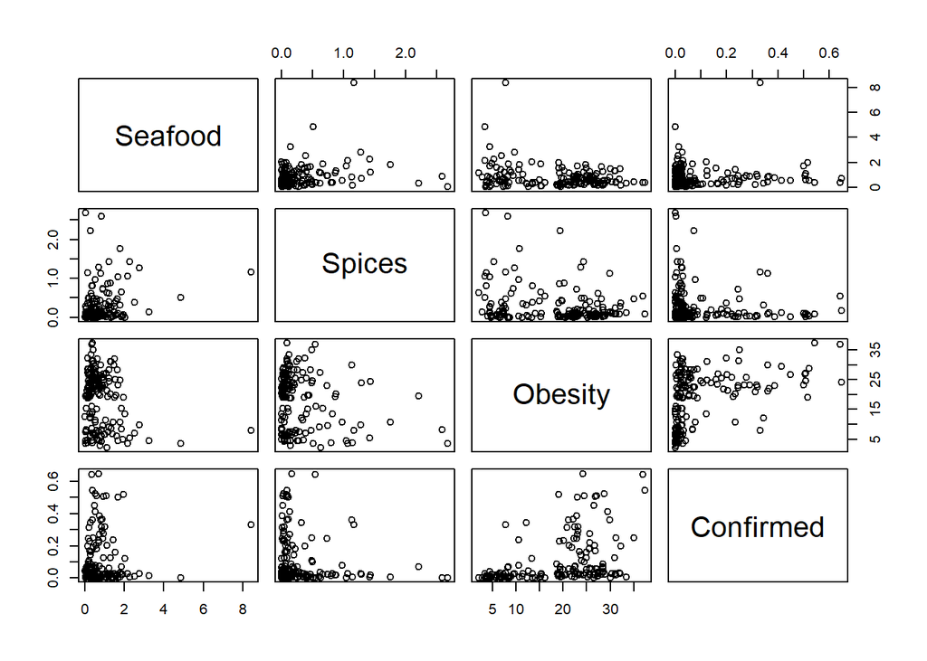

```r
pairs(corona_new[c("Seafood","Spices","Obesity","Confirmed")])
```

이번에는 대부분의 행렬이 무작위 구름처럼 보인다. 전에 생성했던 산포도에 비해, 종속변수와 낮은 상관관계를 가질 것이라고 예측 할 수 있다. 이중에서, **Obesity**와 **Confirmed**의 관계가 유일하게 어떤 추세를 보이는 것 같다. 다음으로는, 더 자세한 산포도 행렬을 생성한다.

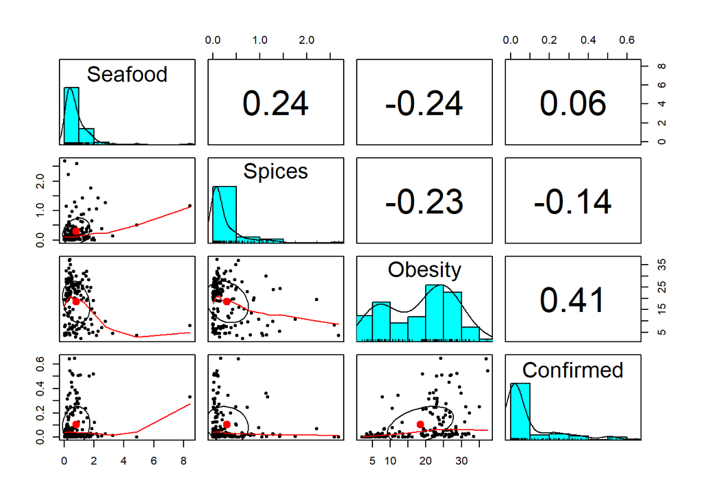

```r
pairs.panels(corona_new[c("Seafood","Spices","Obesity","Confirmed")])
```

산포도를 보면, 많은 타원모양의 객체가 원에 가까운 모양을 가지고, 상관관계가 0에 가까운것을 보인다. 앞서 관찰한 산포도행렬로 예측했던 결과이다. **Obesity**와 **Confirmed**에 대한 타원은 위쪽으로 늘어졌으며, **0.41**에 가까운 양의 상관관계를 보여준다. 즉, **Obesity**이 높을수록, **Confirmed**가 높아지는 것으로 볼 수 있다.

### 3단계: 데이터로 모델 훈련

R에서 선형 회귀 모델을 데이터에 적합시키려면 r에 내장되어 있는 **stats**패키지의 **lm()**함수를 사용할 수 있다. 다음 명령은, 여섯개의 독립 변수를 코로나 발병률에 연관시키는 선형 회귀 모델을 적합시킨다. 모델을 설명하고자 **틸드문자(~)**을 사용한다. 종속변수 **Confirmed**는 틸드의 왼쪽으로 가고, 나머지 독립변수들은 **+**기호로 분리돼 오른쪽으로 간다. 모델 구축 후, 모델 객체 이름을 입력한다.

```r
corona_model <- lm(Confirmed ~ Animal_Products + Animal_fats + Vegetal_Products +
                     Seafood + Spices + Obesity, data=corona_new)
corona_model
```

```
##
## Call:
## lm(formula = Confirmed ~ Animal_Products + Animal_fats + Vegetal_Products +
##     Seafood + Spices + Obesity, data = corona_new)
##
## Coefficients:
##      (Intercept)   Animal_Products       Animal_fats  Vegetal_Products
##       120.634935         -2.412844          0.004699         -2.414004
##          Seafood            Spices           Obesity
##         0.027316         -0.023159          0.005932
```

**베타 계수(Coefficient)**는 각 특징에 대해 하나가 증가하고 다른 값은 모두 고정됐다고 가정할 때 코로나 발병률 추정치의 증가를 나타낸다. 예를들어, 다른 모든 것은 같다고 가정하고 **Obestiy**과 **Seafood**값이 높을수록 코로나 발병률이 각각 **0.006%**와 **0.027%**정도로 높아질 것으로 예상한다. 또한, 똑같은 조건에서 **Animal Product**가 증가할 때, 코로나 발병률이 **2.4%**정도 낮아 질것이라는 결과가 나왔다.  
이는 전에 산포도 행렬에서 양의 상관관계를 보였던 것과 좀 다른 것을 관찰할 수 있다.

### 4단계: 모델 성능 평가

**corona_model**을 이용하여 얻은 **계수 추정치**는 독립변수가 종속 변수와 얼마나 연관되어 있는지 알려주지만, 모델이 데이터에 얼마나 잘 맞는지는 알려주지 않는다. 모델 성능을 평가하기 위해 **summary()**명령을 사용한다.

```r
summary(corona_model)
```

```
##
## Call:
## lm(formula = Confirmed ~ Animal_Products + Animal_fats + Vegetal_Products +
##     Seafood + Spices + Obesity, data = corona_new)
##
## Residuals:
##      Min       1Q   Median       3Q      Max
## -0.21533 -0.08824 -0.02389  0.03411  0.49508
##
## Coefficients:
##                    Estimate Std. Error t value Pr(>|t|)
## (Intercept)      120.634935 125.394844   0.962   0.3375
## Animal_Products   -2.412844   2.507811  -0.962   0.3375
## Animal_fats        0.004699   0.004482   1.049   0.2961
## Vegetal_Products  -2.414004   2.507876  -0.963   0.3373
## Seafood            0.027316   0.012655   2.158   0.0325 *
## Spices            -0.023159   0.024954  -0.928   0.3548
## Obesity            0.005932   0.001388   4.274 3.36e-05 ***
## ---
## Signif. codes:  0 '***' 0.001 '**' 0.01 '*' 0.05 '.' 0.1 ' ' 1
##
## Residual standard error: 0.1352 on 153 degrees of freedom
## Multiple R-squared:  0.223,  Adjusted R-squared:  0.1926
## F-statistic: 7.319 on 6 and 153 DF,  p-value: 6.84e-07
```

## (2) ANN으로 코로나 발병률 모델링

**인공신경망(Artificial Neural Network)**은 생물학적 뇌가 감각 입력의 자극에 어떻게 반응하는지를 이해해서 유도한 모델을 이용한다. 신경세포의 기본 단위 **neuron**을 따라하여 **artificial nueron**또는 **node**를 사용한다. ANN은 계산량이 많고 복잡한 대신에 좋은 결과를 낸다는 장점이 있다.

분석에 앞서, **ANN**은 중요한 몇가지 특성을 가진다.

- **활성 함수(activation function)**
  - 뉴런의 순 입력 신호를 하나의 출력 신호로 변환해서 네트워크에 더 멀리 퍼지게 한다. 일반적으로, **시그모이드 활성 함수(sigmoid activation function)**을 많이 사용한다. 이 함수는 전체 입력 범위에서 미분 가능하여, **ANN 최적화 알고리즘**을 만드는데 큰 장점을 가진다.

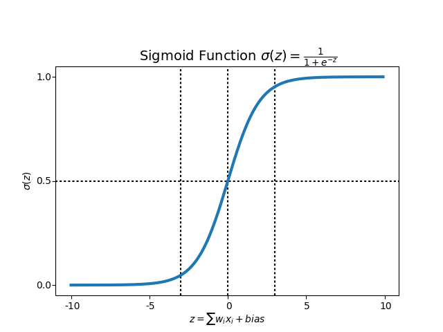

- **네트워크 토폴로지(network topology)**
  - 인공신경망의 구조를 나타낸다.모델의 계층수, 계층 별 노드 개수, 정보가 역방향으로 이동할 수 있는 루프에 따라 구별된다. 다음 사진은 한개의 **hidden layer**을 추가한 다층 네트워크이다.

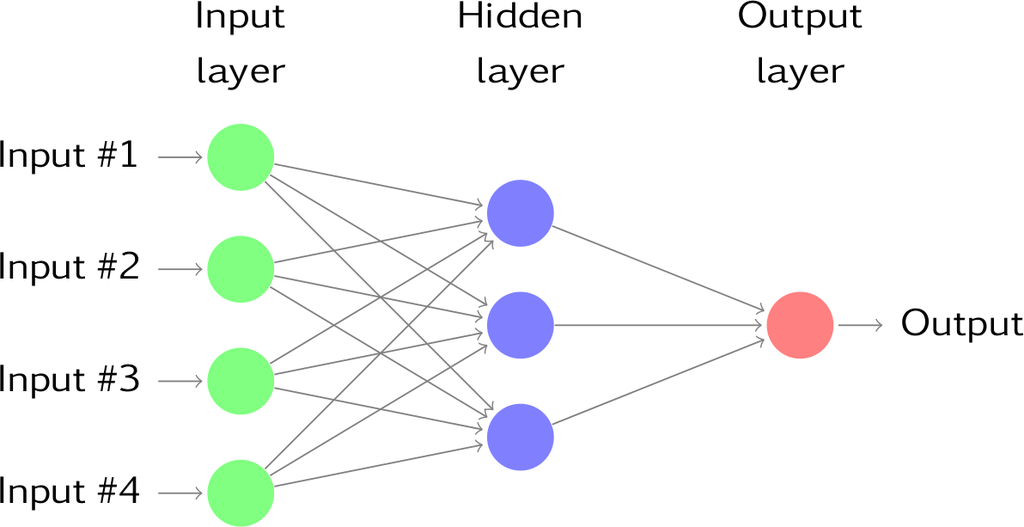

- **훈련 알고리즘(training algorithm)**
  - 입력 신호에 비례해서 뉴런을 억제하거나 흥분시키고자 연결 가중치를 설정하는 방식을 명시한다.가중치는 알고리즘의 오차를 최소화 시키기위해 **learning rate**만큼 변경한다.

이러한 특성을 이해하고 실제 데이터 분석을 해보고자 한다.

### 1단계: 데이터 탐색 및 준비

앞서 (1)Linear regression에서 사용한 **corona_new**데이터를 이용할 것이다.

```r
str(corona_new)
```

```
## 'data.frame':    160 obs. of  7 variables:
##  $ Animal_Products : num  21.6 32 14.4 15.3 27.7 ...
##  $ Animal_fats     : num  6.222 3.417 0.897 1.313 4.669 ...
##  $ Vegetal_Products: num  28.4 18 35.6 34.7 22.3 ...
##  $ Seafood         : num  0.0327 0.1445 0.2008 1.4155 1.5263 ...
##  $ Spices          : num  0.2776 0 0.1568 0.0103 0.3591 ...
##  $ Obesity         : num  4.5 22.3 26.6 6.8 19.1 28.5 20.9 30.4 21.9 19.9 ...
##  $ Confirmed       : num  0.039969 0.039783 0.021642 0.000274 0.026804 ...
```

신경망은 입력 데이터가 0 주변의 좁은 범위로 조정될 때 효과적으로 작동하기 때문에, 정규화를 통해 데이터를 재조정 해야한다. 데이터가 비정규직이기 때문에 0-1범위로 정규화를 하는 것이 적절하다. **normalize**함수는 다음과 같이 정의된다.

```r
normalize <- function(x) {
  return((x-min(x))/(max(x)-min(x)))
}
```

위 함수를 실행 후, **lapply()** 함수를 통해 **corona_new**데이터 프레임의 모든 열에 **normalize**함수를 적용한다.

```r
corona_norm <- as.data.frame(lapply(corona_new,normalize))
```

원래의 최소,최대 발병률이 0과 1로 바뀐것을 볼 수있다.

```r
summary(corona_new$Confirmed)
```

```
##      Min.   1st Qu.    Median      Mean   3rd Qu.      Max.
## 0.0000941 0.0097051 0.0280948 0.1031408 0.1283605 0.6480645
```

```r
summary(corona_norm$Confirmed)
```

```
##    Min. 1st Qu.  Median    Mean 3rd Qu.    Max.
## 0.00000 0.01483 0.04321 0.15903 0.19795 1.00000
```

### 2단계: 데이터로 모델 훈련

임의의 순서로 정렬되어 있던 데이터를 **75%**는 **훈련 집합**, **25%**는 **테스트 집합**으로 분리한다. 훈련 데이터 셋은 신경망을 구축하고자 사용할 것이고, 테스트 데이터셋은 모델평가를 위해 사용할 것이다.

```r
corona_train <- corona_norm[1:120,]
corona_test <- corona_norm[121:160,]
```

음식 섭취량, 비만률과 코로나 발병률 사이에 관계를 모델링 하고자 **다층피드포워드** 신경망을 사용한다.표쥰 신경망의 구현과 네트워크 토폴로지를 그리는함수를 제공하는 **library(neuralnet)**로 패키지를 로드한다.  
아래의 함수에서 **confirmed**는 종속변수, **+**로 연결된 나머지 6개의 변수는 독립변수를 의미한다. 은닉노드의 기본값은 1이므로, **훈련 집합**을 사용하여 은닉 노드가 하나인 신경망 객체를 반환한다.

```r
library(neuralnet)
corona_model2 <- neuralnet(Confirmed ~ Animal_Products + Animal_fats + Vegetal_Products +
                             Seafood + Spices + Obesity, data=corona_train)
```

생성한 모델을 **plot()**함수로 시각화한다.

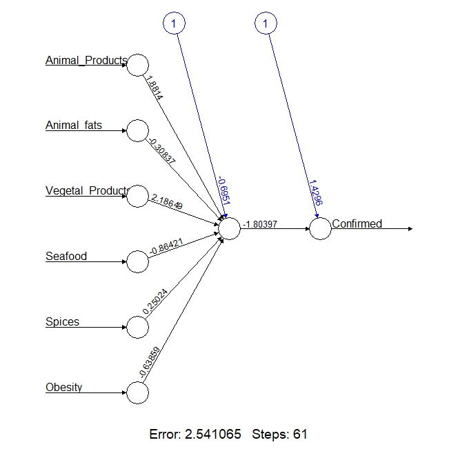

```r
plot(corona_model2)
```

이 모델의 왼쪽에는 각 독립변수의 **입력노드**가 하나씩 있고, 그 옆에 하나의 **은닉노드**와 코로나 발병률을 예측하는 하나의 **출력 노드**가 있다. 각 연결에 써져있는 숫자는 가중치이고, 숫자 1로 써있는 노드는 바이어스 항이다.  
**Error**는 **오차제곱합(SSE)**으로, 예측 값 빼기 실제 값의 제곱을 합한 것이다. **SSE**가 낮아질수록, 예측성능이 좋은 것을 의미한다. 이 값은 훈련 데이터에 대한 모델의 성능평가 하는데는 도움되지만, 처음 보는 데이터에 대해서는 예측하기 어렵다.

### 3단계: 모델 성능 평가

테스트 데이터셋에 대해 예측을 생성하기 위해 **compute()**를 사용한다. 이 함수는 두개의 구성요소로 된 리스트를 반환하는데, 이를 **model_results**변수에 넣는다.

```r
model_results <- compute(corona_model2, corona_test[1:6])
```

**net.result**는 모델의 예측 값을 가지기 때문에, 코로나 발병률의 예측값을 **predicted_corona**변수에 넣는다.

```r
predicted_corona <- model_results$net.result
```

예측된 코로나 발병률과 실제 값의 상관관계를 측정하기 위해 **cor()**함수를 사용한다.

**앞으로 관찰할 cor()값들은 실행할때마다 다시 모델을 생성하면서 계산에 차이가 나기 때문에 조금씩 값이 변할수도 있다는 점을 유의해야한다.**

```r
cor(predicted_corona, corona_test$Confirmed)
```

```
##           [,1]
## [1,] 0.5488165
```

상관관계가 1에 가까울수록 강한 선형 관계를 가진다. 이 모델은 약 0.5의 약하지 않은 상관 관계를 나타낸다. 현재,모델이 하나의 은닉노드만을 가졌기 때문에, 모델의 성능에 개선 될 여지를 기대할 수있다.

### 4단계: 모델 성능 개선

모델의 성능을 개선하기 위해 은닉 노드의 개수를 증가시켜 볼 것이다. **nueralnet()**함수를 사용하는데 **hidden=4**파라미터를 추가한다. 히든노드를 1개에서 4개로 늘린다는 말이다.

```r
corona_model3 <- neuralnet(Confirmed ~ Animal_Products + Animal_fats + Vegetal_Products +
                             Seafood + Spices + Obesity,
                           data=corona_train, hidden=4)
```

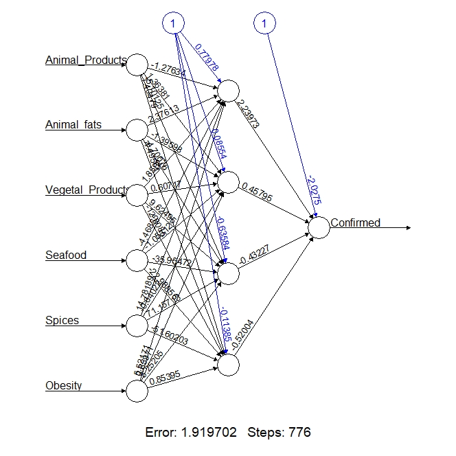

```r
plot(corona_model3)
```

앞서 한것처럼, **compute()**함수와 **net.result**를 이용하여 새로운 코로나 발병률의 모델과의 관계를 알아보겠다.

```r
model_results2 <- compute(corona_model3, corona_test[1:6])
predicted_corona2 <- model_results2$net.result
cor(predicted_corona2, corona_test$Confirmed)
```

```
##           [,1]
## [1,] 0.5072104
```

아까와 비교했을때 비슷하지만 조금 낮아진 상관관계를 관찰할 수 있다. 따라서, 은닉노드를 추가한다고 해서 꼭 모델 성능이 개선된다는 것은 아니라는 걸 관찰 할 수있다. 너무 많은 은닉노드는 **과적합(overfitting)**으로 인해, 모델의 성능을 떨어뜨릴수 있다.

다음으로는, 초반에 언급했던 **활성 함수(activation function)**을 이용하여, 모델 성능을 개선해보고자 한다.

### 5단계:모델 성능개선

활성함수는 **log(1+exp(x))**로 정의된다. **set.seed()**를 통해 난수를 발생시킨후, **neuralnet()**함수를 통해 모델을 생성한다. 이 때, **hidden=c(4,4)**로 각각 4개 노드를 가진 2 계층 네트워크를 형성하고, 소프트플러스 활성함수를 사용한다.

```r
softplus <- function(x) {log(1+exp(x))}
set.seed(12345)
corona_model4 <- neuralnet(Confirmed ~ Animal_Products + Animal_fats + Vegetal_Products +
                             Seafood + Spices + Obesity,
                           data=corona_train, hidden=c(4,4),
                           act.fct=softplus)
```

만들 모델을 **plot()**을 사용하여 시각화한다.

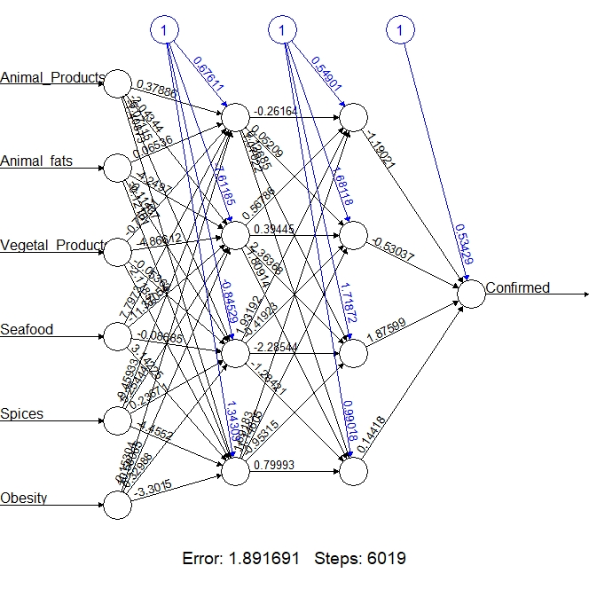

```r
plot(corona_model4)
```

그리고, 예측 값과 실제 코로나 발병률의 상관관계를 다음과 같이 계산한다.

```r
model_results3 <- compute(corona_model4, corona_test[1:6])
predicted_corona3 <- model_results3$net.result
cor(predicted_corona3, corona_test$Confirmed)
```

```
##           [,1]
## [1,] 0.5804032
```

예측과 실제 강도의 상관관계는 약 0.58로 지금까지 모델중에서 제일 좋은 성능을 갖고있음을 보여준다. 하지만, 0.58은 여전히 강한 상관관계를 의미하진 않는다.